# Data606_Chapter3

Sedo Oh

September 24, 2017

## 3.2 Area under the curve, Part II.

What percent of a standard normal distribution N ( mu =0, sd = 1) is found in each region? Be sure to draw a graph. (a) Z > - 1.13(b) Z < 0.18(c) Z > 8(d) |Z| < 0.5

```r
##Taking code from this site for graphing: http://www.statmethods.net/advgraphs/probability.html

normalPlot <- function(mean=0,sd=1,lb,ub){
  x <- seq(-4,4,length=100)*sd + mean
hx <- dnorm(x,mean,sd)

plot(x, hx, type="n",
  main="Normal Distribution", axes=FALSE)

i <- x >= lb & x <= ub
lines(x, hx)
polygon(c(lb,x[i],ub), c(0,hx[i],0), col="red")
}


##a
1-pnorm(-1.13)
```

```
## [1] 0.8707619
```

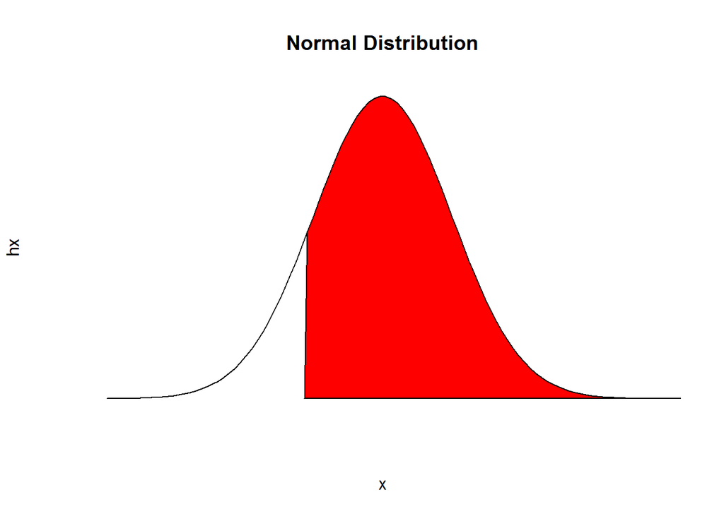

```r
normalPlot(lb=-1.13,ub=100)
```

```r
##b
pnorm(0.18)
```

```
## [1] 0.5714237
```

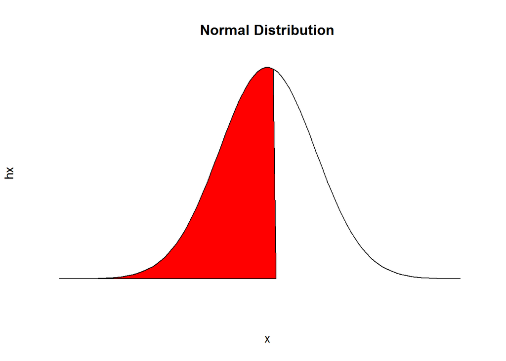

```r
normalPlot(lb=-100,ub=0.18)
```

```r
##c
1-pnorm(8)
```

```
## [1] 6.661338e-16
```

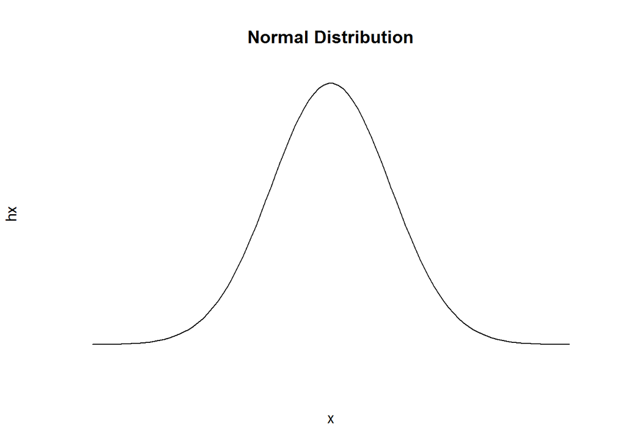

```r
normalPlot(lb=8,ub=100)
```

```r
##d
pnorm(0.5)-pnorm(-0.5)
```

```
## [1] 0.3829249
```

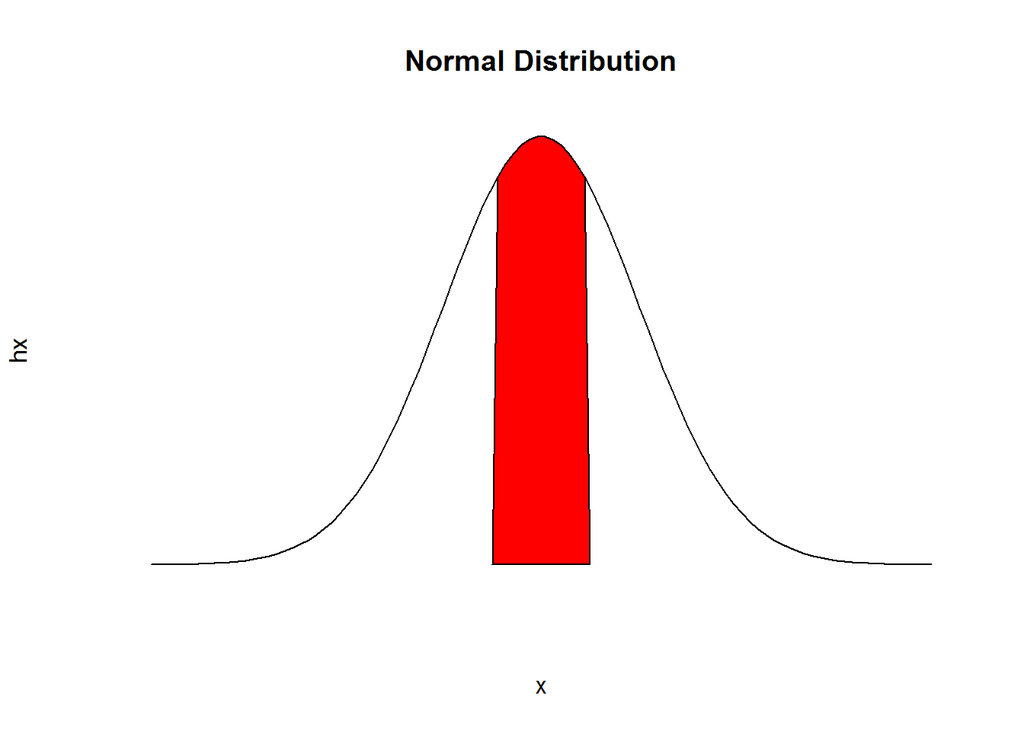

```r
normalPlot(lb=-0.5,ub=0.5)
```

## 3.4 Triathlon times, Part I.

In triathlons, it is common for racers to be placed into age and gender groups. Friends Leo and Mary both completed the Hermosa Beach Triathlon, where Leo competed in the Men, Ages 30 - 34 group while Mary competed in the Women, Ages 25 - 29 group. Leo completed the race in 1:22:28 (4948 seconds), while Mary completed the race in 1:31:53 (5513 seconds). Obviously Leo finished faster, but they are curious about how they did within their respective groups. Can you help them? Here is some information on the performance of their groups:

. The finishing times of the Men, Ages 30 - 34 group has a mean of 4313 seconds with a standard deviation of 583 seconds.

. The finishing times of the Women, Ages 25 - 29 group has a mean of 5261 seconds with a standard deviation of 807 seconds.

. The distributions of finishing times for both groups are approximately Normal.

Remember: a better performance corresponds to a faster finish.

1. Write down the short-hand for these two normal distributions

Men: N(mu=4313,sd=583) Women: N(mu=5261, sd=807)

2. What are the Z-scores for Leo’s and Mary’s finishing times? What do these Z-scores tell you?

```r
(4948-4313)/583
```

```
## [1] 1.089194
```

```r
pnorm(1.09)
```

```
## [1] 0.8621434
```

```r
(5513-5261)/807
```

```
## [1] 0.3122677
```

```r
pnorm(0.31)
```

```
## [1] 0.6217195
```

The Z-Scores tells how Leo and Mary did respective to their own group. Leo’s Z-Score of 1.09 means he did worse than 86 percent of the population. Mary’s Z-Score of 0.31 means she did worse than 62% of the population.

3. Did Leo or Mary rank better in their respective groups? Explain your reasoning.

With Leo’s having Z-score of 1.09 and Mary having 0.31, Mary did much better than Leo respective each person’s group, since lower seconds means, the person took less time to finish the race.

4. What percent of the triathletes did Leo finish faster than in his group?

Approximately 14%.

5. What percent of the triathletes did Mary finish faster than in her group?

Approximately 38%.

6. If the distributions of finishing times are not nearly normal, would your answers to parts b-e change? Explain your reasoning.

Yes, it would change. The answers are based on normal distribution assumption. If the distribution is skewed and especially if the number of participants is low, then other types of analysis has to be used to determine how the person did in respective group.

## 3.18 Heights of female college students.

Below are heights of 25 female college students.  
(a) The mean height is 61.52 inches with a standard deviation of 4.58 inches. Use this information to determine if the heights approximately follow the 68-95-99.7% Rule.

```r
exam <- c(54, 55, 56, 56, 57, 58, 58, 59, 60, 60, 60, 61, 61, 62, 62, 63, 63, 63, 64, 65, 65, 67, 67, 69, 73)

##68% Range
ub = 61.52+4.58
lb = 61.52-4.58
sum(exam > lb & exam < ub) / length(exam)
```

```
## [1] 0.68
```

```r
##95% Range
ub = 61.52+2*4.58
lb = 61.52-2*4.58
sum(exam > lb & exam < ub) / length(exam)
```

```
## [1] 0.96
```

```r
##99.7% Range
ub = 61.52+3*4.58
lb = 61.52-3*4.58
sum(exam > lb & exam < ub) / length(exam)
```

```
## [1] 1
```

Indeed, it follows the rule.

2. Do these data appear to follow a normal distribution? Explain your reasoning using the graphs below.

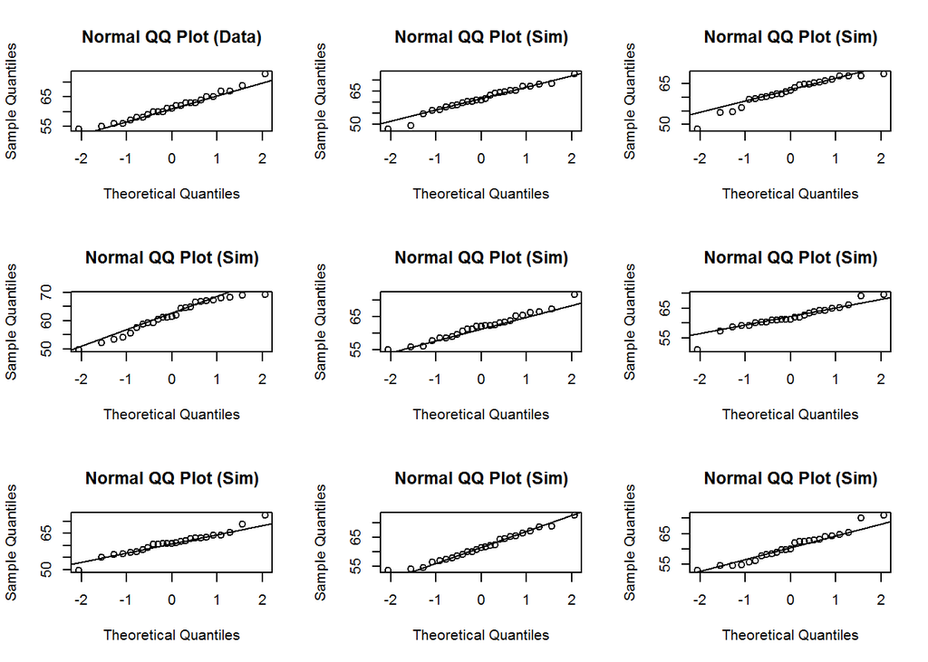

```r
qqnormsim <- function(dat){
  par(mfrow = c(3,3))
  qqnorm(dat, main = "Normal QQ Plot (Data)")
  qqline(dat)

  for(i in 1:8){
    simnorm <- rnorm(n = length(dat), mean = mean(dat), sd = sd(dat))
    qqnorm(simnorm,main = "Normal QQ Plot (Sim)")
    qqline(simnorm)
  }

  par(mfrow = c(1,1))
}
qqnormsim(exam)
```

## 3.22 Defective rate.

A machine that produces a special type of transistor (a component of computers) has a 2% defective rate. The production is considered a random process where each transistor is independent of the others.

1. What is the probability that the 10th transistor produced is the first with a defect?

```r
p = .02
n = 10
(1-p)^(n-1)*p
```

```
## [1] 0.01667496
```

2. What is the probability that the machine produces no defective transistors in a batch of 100?

```r
n=100
(1-p)^n
```

```
## [1] 0.1326196
```

3. On average, how many transistors would you expect to be produced before the first with a defect? What is the standard deviation?

```r
## Number of Transistors to see before first
1/p
```

```
## [1] 50
```

```r
## SD
sqrt((1-p)/p^2)
```

```
## [1] 49.49747
```

4. Another machine that also produces transistors has a 5% defective rate where each transistor is produced independent of the others. On average how many transistors would you expect to be produced with this machine before the first with a defect? What is the standard deviation?

```r
p=.05
## Number of Transistors to see before first
1/p
```

```
## [1] 20
```

```r
## SD
sqrt((1-p)/p^2)
```

```
## [1] 19.49359
```

5. Based on your answers to parts (c) and (d), how does increasing the probability of an event affect the mean and standard deviation of the wait time until success?

Increasing the probability decreases both the wait time and standard deviation.

## 3.38 Male children.

While it is often assumed that the probabilities of having a boy or a girl are the same, the actual probability of having a boy is slightly higher at 0.51. Suppose a couple plans to have 3 kids.

1. Use the binomial model to calculate the probability that two of them will be boys.

```r
Pb = 0.51
dbinom(2,3,Pb)
```

```
## [1] 0.382347
```

2. Write out all possible orderings of 3 children, 2 of whom are boys. Use these scenarios to calculate the same probability from part (a) but using the addition rule for disjoint outcomes. Confirm that your answers from parts (a) and (b) match.

gbb bgb bbg

```r
3*0.51*0.51*0.49
```

```
## [1] 0.382347
```

Matches!

3. If we wanted to calculate the probability that a couple who plans to have 8 kids will have 3 boys, briefly describe why the approach from part (b) would be more tedious than the approach from part (a).

There are going to be 56 different combinations to write out. That’s too many to write than just using the formula.

## 3.42 Serving in volleyball.

A not-so-skilled volleyball player has a 15% chance of making the serve, which involves hitting the ball so it passes over the net on a trajectory such that it will land in the opposing team’s court. Suppose that her serves are independent of each other.

1. What is the probability that on the 10th try she will make her 3rd successful serve?

```r
dbinom(2, 9, 0.15)*0.15
```

```
## [1] 0.03895012
```

2. Suppose she has made two successful serves in nine attempts. What is the probability that her 10th serve will be successful?

0.15 since every shot is independent.

3. Even though parts (a) and (b) discuss the same scenario, the probabilities you calculated should be different. Can you explain the reason for this discrepancy?

They are not the same. (a) is looking at the probability of success including making two serves within 9 attempts.